# Analyzing Voter Turnout in 2016 for Alaska

- Show All Code
- Hide All Code

Chunting Zheng, Justin Liu, Jasper Wu, Sanaz Ebrahimi

## Research Question

How did various election demographics affect voter turnout in the 2016 Alaska general election?

## Executive Summary

In this report, we will first perform exploratory data analysis to identify and understand patterns in the dataset at a high level. Then, we will conduct detailed hypothesis testing to investigate the effect of election demographics (age, gender, party registration, ethnicity, county, education, and income) on voter turnout under different scenarios. We will perform a $\chi^2$-test for every demographic feature against voter turnout. Moreover, several two sample $Z$-tests for proportions will be carried out to assess the plausibility of different hypotheses. Our results suggest that 1) there is an association between each demographic feature and voter turnout, and 2) females and 60+ year old citizens were more likely to vote in the general election. Finally, we will predict the voter turnout (either yes or no) in $2016$ for Alaska. After building logistic regression, decision tree, random forest, gradient-boosted tree, and neural network models to predict voter turnout, the results showed that the gradient-boosted tree model performs the best in terms of the area under both the ROC and PR curves. However, the logistic regression model was comparable in performance and offered the best interpretability of the results.

## Introduction

Effective campaigns use limited resources to efficiently net enough votes for their candidate to win. Running a campaign requires spending money in the right places, running cost-effective programs, and focusing on the people most likely to be swayed by those programs. Therefore, it is essential to identify which voters should be the targets of get-out-the-vote (GOTV) activities. In the presidential election, the voter turnout is higher than in any other political contest. A higher turnout means a high percentage of voters are almost certain to vote and need little encouragement to show up at the polls. In $2016$, Alaska adopted automatic voter registration, increasing the number of registered voters by more than $70,000$.

Moreover, many political scientists will tell us that demographics are significant predictors of voting participation. This report reminds us to convert demographic information into a schema that predicts turnout for individual voters. Our project examines how election demographics affected voter turnout in the $2016$ Alaska general election, an event of potential interest to political scientists and the electorate.

## Data

```python
from pyspark.ml.feature import StringIndexer, OneHotEncoder, StandardScaler, VectorAssembler, PCA, Bucketizer
from pyspark.ml.classification import LogisticRegression, DecisionTreeClassifier, RandomForestClassifier, GBTClassifier, MultilayerPerceptronClassifier
from pyspark.ml.evaluation import BinaryClassificationEvaluator
from pyspark.ml.tuning import CrossValidator, ParamGridBuilder, CrossValidatorModel
from pyspark.sql.functions import isnan, when, count, col, regexp_replace
from statsmodels.stats.proportion import proportions_ztest
from pyspark.ml.stat import ChiSquareTest
from pyspark.sql.types import DoubleType
from pyspark.sql import functions as F
from pyspark.ml import Pipeline
import matplotlib.pyplot as plt
import pandas as pd
import seaborn as sns
import altair as alt
import numpy as np
```

#### Loading the data into a Spark DataFrame

```python
gcs_path = "gs://pstat135-voter-file/VM2Uniform/VM2Uniform--AK--2021-02-03"
df = spark.read.parquet(gcs_path)
```

#### Selecting columns that we will be using in our analysis

```python
df = df.select("LALVOTERID", "Voters_Gender", "Voters_Age", "Parties_Description",
               "EthnicGroups_EthnicGroup1Desc", "County", "CommercialData_Education",
               "CommercialData_EstimatedHHIncomeAmount", "General_2016")

[df.count(), len(df.columns)]
```

```
[548259, 9]
```

```python
df.printSchema()
```

```
root
 |-- LALVOTERID: string (nullable = true)
 |-- Voters_Gender: string (nullable = true)
 |-- Voters_Age: string (nullable = true)
 |-- Parties_Description: string (nullable = true)
 |-- EthnicGroups_EthnicGroup1Desc: string (nullable = true)
 |-- County: string (nullable = true)
 |-- CommercialData_Education: string (nullable = true)
 |-- CommercialData_EstimatedHHIncomeAmount: string (nullable = true)
 |-- General_2016: string (nullable = true)
```

#### Summary of missing values for each column

```python
# Get number of observations with missing values for each variable
missing = df.select([count(when(col(c).isNull(), c)).alias(c) for c in df.columns])\
    .toPandas()\
    .melt(ignore_index = False)\
    .reset_index()\
    .rename(columns = {"value": "missing"})\
    .drop(columns = "index")

# Add column for proportion of missing values
missing["prop_missing"] = missing["missing"] / df.count()
missing.sort_values("prop_missing", ascending = False).reset_index(drop = True)
```

|  | variable | missing | prop_missing |
| --- | --- | --- | --- |
| 0 | CommercialData_Education | 284813 | 0.519486 |
| 1 | General_2016 | 268226 | 0.489232 |
| 2 | Voters_Age | 215368 | 0.392822 |
| 3 | CommercialData_EstimatedHHIncomeAmount | 95658 | 0.174476 |
| 4 | EthnicGroups_EthnicGroup1Desc | 71026 | 0.129548 |
| 5 | Voters_Gender | 66 | 0.000120 |
| 6 | LALVOTERID | 0 | 0.000000 |
| 7 | Parties_Description | 0 | 0.000000 |
| 8 | County | 0 | 0.000000 |

#### Dropping rows with NULL values on selected columns

```python
df = df.na.drop(subset=df.columns[:-1])
[df.count(), len(df.columns)]
```

```
[187065, 9]
```

#### Converting data and renaming columns

```python
# Split the column on commas into a list
split_col = F.split(df["CommercialData_Education"], '-')
# Put the first value of the list into a new column
df = df.withColumn("Education", split_col.getItem(0))
df = df.drop("CommercialData_Education")

# Inspect results
df[["Education"]].show(5)
```

```
+-------------+
|    Education|
+-------------+
| Grad Degree |
| Grad Degree |
| Bach Degree |
|Some College |
| Bach Degree |
+-------------+
only showing top 5 rows
```

```python
# Note that the column `CommercialData_EstimatedHHIncomeAmount` is a string type
df = df.withColumn(
    "Income", F.translate(F.col("CommercialData_EstimatedHHIncomeAmount"), "$,", "").cast(DoubleType())
).drop("CommercialData_EstimatedHHIncomeAmount")

df[["Income"]].show(5)
```

```
+--------+
|  Income|
+--------+
| 75000.0|
|123000.0|
| 76000.0|
| 76000.0|
|143000.0|
+--------+
only showing top 5 rows
```

```python
df = df.withColumn(
    "Age", col("Voters_Age").cast("int")
).drop("Voters_Age")

df = df.na.fill({"General_2016": "N"})
df.printSchema()
```

```
root
 |-- LALVOTERID: string (nullable = true)
 |-- Voters_Gender: string (nullable = true)
 |-- Parties_Description: string (nullable = true)
 |-- EthnicGroups_EthnicGroup1Desc: string (nullable = true)
 |-- County: string (nullable = true)
 |-- General_2016: string (nullable = false)
 |-- Education: string (nullable = true)
 |-- Income: double (nullable = true)
 |-- Age: integer (nullable = true)
```

```python
income_bucketizer = Bucketizer(splits=[0, 45195, 135586, float('inf')],
                               inputCol="Income", outputCol = "Income_bin")

# Apply buckets to "Income" column
df = income_bucketizer.transform(df)

df = df.withColumnRenamed("Voters_Gender", "Gender")\
    .withColumnRenamed("Parties_Description", "Party")\
    .withColumnRenamed("EthnicGroups_EthnicGroup1Desc", "Ethnicity")

df.toPandas().head()
```

|  | LALVOTERID | Gender | Party | Ethnicity | County | General_2016 | Education | Income | Age | Income_bin |
| --- | --- | --- | --- | --- | --- | --- | --- | --- | --- | --- |
| 0 | LALAK176775952 | M | Non-Partisan | European | FAIRBANKS NORTH STAR | Y | Grad Degree | 75000.0 | 70 | 1.0 |
| 1 | LALAK410115488 | M | Non-Partisan | European | FAIRBANKS NORTH STAR | Y | Grad Degree | 123000.0 | 59 | 1.0 |
| 2 | LALAK177038764 | F | Democratic | European | FAIRBANKS NORTH STAR | Y | Bach Degree | 76000.0 | 51 | 1.0 |
| 3 | LALAK176844885 | M | Non-Partisan | European | FAIRBANKS NORTH STAR | Y | Some College | 76000.0 | 62 | 1.0 |
| 4 | LALAK177017449 | F | Unknown | European | FAIRBANKS NORTH STAR | Y | Bach Degree | 143000.0 | 37 | 2.0 |

## Methods

### Exploratory Data Analysis

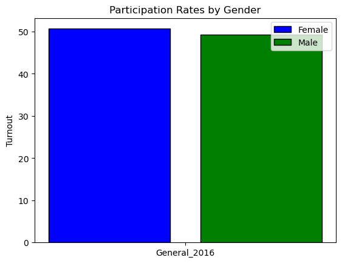

```python
total_Gvote_count = df.where(F.col("General_2016") == "Y").count()
gender_general = df.groupBy("Gender", "General_2016")\
    .agg(F.count("LALVOTERID")\
    .alias("Gender_Count"))\
    .where(F.col("General_2016") == "Y")\
    .withColumn("Vote_Rate", F.round(F.col("Gender_Count")/total_Gvote_count*100, 2))\
    .toPandas()

total_count = df.groupBy("Gender")\
    .agg(F.count("LALVOTERID")\
    .alias("Total_Count"))

# Barplot to visualize both the tables from above against each other
X = ["General_2016"]
YF = [gender_general[gender_general.Gender == "F"].Vote_Rate.iloc[0]]
ZM = [gender_general[gender_general.Gender == "M"].Vote_Rate.iloc[0]]

X_axis = np.arange(len(X))

plt.bar(X_axis - 0.25/2, YF, width=0.2, color="b", edgecolor="black", label="Female")
plt.bar(X_axis + 0.25/2, ZM, width=0.2, color="g", edgecolor="black", label="Male")

plt.xticks(X_axis, X)
plt.ylabel("Turnout")
plt.title("Participation Rates by Gender")
plt.legend(loc = "upper right")
plt.show()
```

> **Figure 1**: Barplot representing the voter turnout for males and females voting in the $2016$ Alaskan general election.

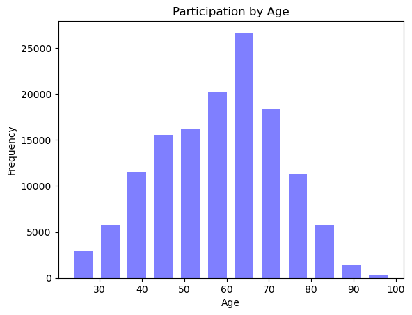

```python
# Histogram showing visualization of age distribution in the 2016 general election in Alaska
df.where(F.col("General_2016") == "Y")\
    .toPandas()["Age"]\
    .plot.hist(bins=12, alpha=0.5, rwidth=0.7, color='b')

plt.xlabel("Age")
plt.title("Participation by Age")
plt.show()
```

> **Figure 2**: Histogram illustrating the frequency of voters in the $2016$ Alaskan general election by age.

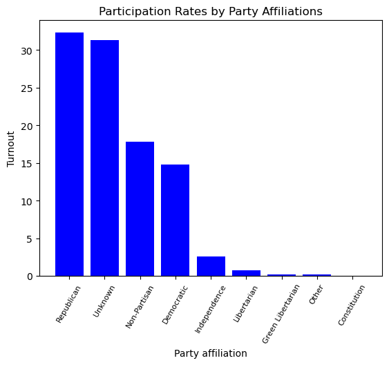

```python
parties_general = df.groupBy("Party", "General_2016")\
    .agg(F.count("LALVOTERID")\
    .alias("Count"))\
    .where(F.col("General_2016") == "Y")\
    .withColumn("Vote_Rate", F.round(F.col("Count")/total_Gvote_count*100, 2))\
    .orderBy(F.desc("Vote_Rate"))\
    .toPandas()

# Barplot showing voter turnout based on party in 2016 general election in Alaska
plt.bar(parties_general["Party"], parties_general["Vote_Rate"], color="b")
plt.xticks(rotation=60, fontsize=8, ha="center");
plt.title("Participation Rates by Party Affiliations")
plt.xlabel("Party affiliation")
plt.ylabel("Turnout")
plt.show()
```

> **Figure 3**: Barplot of voter turnout in the $2016$ Alaskan general election based on party preference.

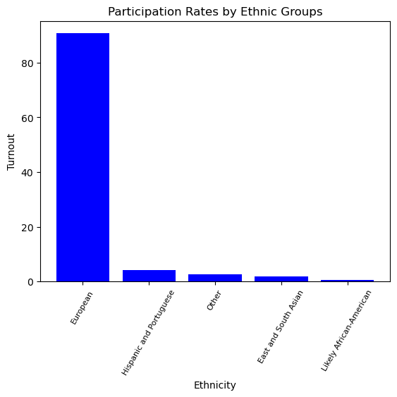

```python
ethnic_general = df.groupBy("Ethnicity", "General_2016")\
    .agg(F.count("LALVOTERID")\
    .alias("Count"))\
    .where(F.col("General_2016") == "Y")\
    .withColumn("Vote_Rate", F.round(F.col("Count")/total_Gvote_count*100, 2))\
    .orderBy(F.desc("Vote_Rate"))\
    .toPandas()

# Barplot of ethnicity versus turnout during the 2016 general election in Alaska
plt.bar(ethnic_general["Ethnicity"], ethnic_general["Vote_Rate"], color="b")
plt.xticks(rotation=60, fontsize=8, ha="center");
plt.title("Participation Rates by Ethnic Groups")
plt.xlabel("Ethnicity")
plt.ylabel("Turnout")
plt.show()
```

> **Figure 4**: Barplot of voter turnout in the $2016$ Alaskan general election based on ethnicity.

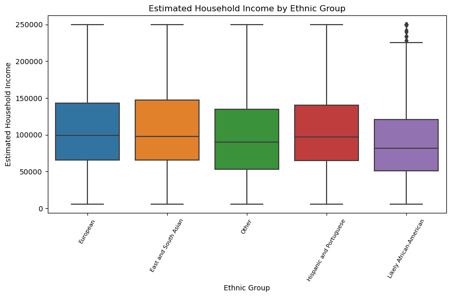

```python
# Boxplots of ethnicity versus estimated household income in Alaska
ethnic_income = df.select("Income", "Ethnicity").toPandas()
plt.figure(figsize=(10,5))
sns.boxplot(x="Ethnicity", y="Income", data=ethnic_income)
plt.title("Estimated Household Income by Ethnic Group")
plt.xticks(rotation=60, fontsize=8, ha="center")
plt.xlabel("Ethnic Group")
plt.ylabel("Estimated Household Income")
plt.show()
```

> **Figure 5**: Multiple comparison box plot showcasing the ranges of estimated household income in the $2016$ Alaskan general election based on ethnicity.

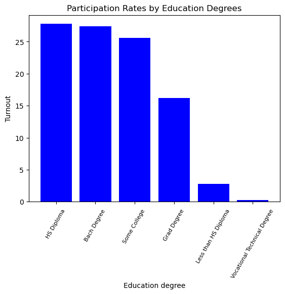

```python
edu_general = df.groupBy("Education", "General_2016")\
    .agg(F.count("LALVOTERID")\
    .alias("Count"))\
    .where(F.col("General_2016") == "Y")\
    .withColumn("Vote_Rate", F.round(F.col("Count")/total_Gvote_count*100, 2))\
    .orderBy(F.desc("Vote_Rate"))\
    .toPandas()

plt.bar(edu_general["Education"], edu_general["Vote_Rate"], color="b")
plt.xticks(rotation=60, fontsize=8, ha="center");
plt.title("Participation Rates by Education Degrees")
plt.xlabel("Education degree")
plt.ylabel("Turnout")
plt.show()
```

> **Figure 6**: Barplot of voter turnout based on education degree in the $2016$ general election in Alaska.

```python
parties_education = df.groupBy("Party", "Education") \
    .count() \
    .toPandas() \
    .sort_values("count", ascending = False) \
    .reset_index(drop = True)

# Bar chart of party affiliations and education level
alt.Chart(parties_education).mark_bar().encode(
    x=alt.X("sum(count)", title="Number of voters"),
    y=alt.Y("Party", sort="-x", title="Party affiliation"),
    color=alt.Color("Education:N", title="Education level")
).properties(
    width = 550
)
```

[interactive chart not shown]

> **Figure 7**: Barplot representing the amount of voters in the $2016$ Alaska general election by both party preference and education level.

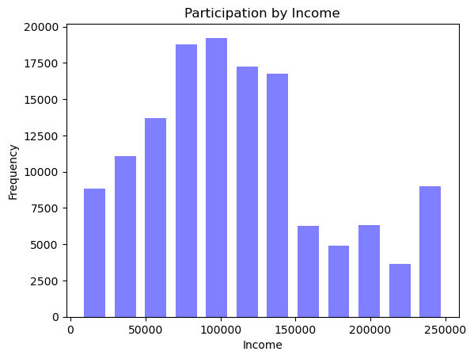

```python
df.where(F.col("General_2016") == "Y")\
    .toPandas()["Income"]\
    .plot.hist(bins=12, alpha=0.5, rwidth=0.7, color='b')

plt.xlabel("Income")
plt.title("Participation by Income")
plt.show()
```

> **Figure 8**: Histogram of voter frequency based solely on income in the $2016$ general election taking place in Alaska.

Another significant predictor of voter turnout is party affiliation. The Republican party brought in the most votes for the general election, hinting that this may have been a red state for the $2016$ race. This idea is backed by the fact that the second most common party, the Democratic party, has a much lower amount of votes than both the “unknown” and “Non-partisan” parties (Figure 3).

The majority of the barplot consists of Europeans. The second largest population is “Hispanic and Portuguese,” but their voter turnout is nowhere near as large as the Europeans. The difference in turnout rates between ethnicities is one of the enormous disparities observed so far and could significantly affect voter outcomes. There are many contextual and historical reasons this could be happening in Alaska. This would be an excellent place for a campaign manager to look into enticing more voters to participate. This barplot refers to the voter turnout rate for the $2016$ general election in Alaska (Figure 4).

As one can see, the most notable differences are that the “East and South Asian” race has the highest median income, whereas the “Likely African-American” race has the lowest median income and a slightly lower quartile range. The side-by-side groups that showed the considerable disparity in voter turnout were “Hispanic and Portuguese” and “European.” This graphic shows they have similar estimated incomes based on their boxplots (Figure 5).

In the $2016$ general election, there is a slight right-skew in the distribution – there are slightly more people on the lower half of the distribution (less than $\$125,000$) compared to those on the higher end (between $\$125,000$ and $\$250,000$). The lowest income ($\le \$45,000$) turns out slightly less than the middle or upper income, but once income reaches $\$55,000$ to $\$150,000$, there is little difference at all (Figure 8).

### Statistical Methods and Results

#### Chi-squared test of independence

The $\chi^2$-test aims at determining whether there is an association between each demographic feature and voter turnout (i.e., whether the variables are independent or related). For each feature, the (feature, voter turnout) pairs are converted into a contingency matrix for which the Chi-squared statistic is computed. The null hypothesis is that the occurence of the outcomes is statistically independent.

```python
age_bucketizer = Bucketizer(splits=[0, 60, float('inf')],
                            inputCol="Age", outputCol="Age_bin")

# apply buckets to "Age" column
df1 = age_bucketizer.transform(df)

# Convert categorical strings to index values
stringIndexer = [StringIndexer(inputCol=column,
                               outputCol=column+"_index") \
                 .fit(df) for column in ["Gender", "Party", "Ethnicity", "County", "Education", "General_2016"]]

pipeline = Pipeline(stages=stringIndexer)
df2 = pipeline.fit(df1).transform(df1) \
    .select("Gender_index", "Party_index", "Ethnicity_index", "County_index", "Education_index",
            "Income_bin", "Age_bin", "General_2016_index")

assembler = VectorAssembler(
    inputCols=["Gender_index", "Party_index", "Ethnicity_index", "County_index",
               "Education_index", "Income_bin", "Age_bin"],
    outputCol="features"
)

vectorized_df = assembler.transform(df2).select("General_2016_index", "features")

vectorized_df.show(5, truncate=False)

r = ChiSquareTest.test(vectorized_df, "features", "General_2016_index").head()
print("pValues: " + str(r.pValues))
print("degreesOfFreedom: " + str(r.degreesOfFreedom))
print("statistics: " + str(r.statistics))
```

```
                                                                                [Stage 72:=============================>                            (2 + 2) / 4]
```

```
+------------------+-----------------------------+
|General_2016_index|features                     |
+------------------+-----------------------------+
|0.0               |[0.0,2.0,0.0,2.0,3.0,1.0,1.0]|
|0.0               |[0.0,2.0,0.0,2.0,3.0,1.0,0.0]|
|0.0               |[1.0,3.0,0.0,2.0,2.0,1.0,0.0]|
|0.0               |[0.0,2.0,0.0,2.0,1.0,1.0,1.0]|
|0.0               |[1.0,0.0,0.0,2.0,2.0,2.0,0.0]|
+------------------+-----------------------------+
only showing top 5 rows

pValues: [0.0,0.0,0.0,0.0,0.0,0.0,0.0]
degreesOfFreedom: [1, 8, 4, 28, 5, 2, 1]
statistics: [184.8369583223074,7157.917830498936,1580.022914498495,1144.2548891675792,2526.3295056151915,454.2971313783404,5745.72713407305]
```

The $p$-values are all $0$ and less than the $0.05$ significance level, so we reject the null hypotheses. That is, there is an association between each demographic feature and voter turnout.

#### Two sample $Z$-test for proportions

The two sample $Z$-test for proportions aims at finding whether there is sufficient evidence at the $0.05$ level to support the claims (a) and (b) below. The sample size is large enough ($n \ge 25)$, so it is appropriate to use the two sample $Z$-test which compares the proportions of the two groups of each variable by deriving a test statistic through dividing the difference between the two population proportion by the standard error of the difference, $Z = \frac{\hat{p}_1 - \hat{p}_2}{SE}$. The $p$-value associated with the test is the area above the test statistic in a standard normal distribution.

**(a) Claim: Female are more likely to vote**

> **Table 1**: Voter Turnout by Gender.

```python
df.groupBy("Gender", "General_2016").count().show()
```

```
[Stage 77:>                                                         (0 + 4) / 4]
```

```
+------+------------+-----+
|Gender|General_2016|count|
+------+------------+-----+
|     F|           N|24234|
|     F|           Y|68777|
|     M|           Y|66909|
|     M|           N|27145|
+------+------------+-----+
```

Let $p_1$ represent the proportion of females who voted and $p_2$ represent the proportion of males who voted. The hypotheses of interest are $H_0: p_1 = p_2$ and $H_a: p_1 > p_2$.

```python
count = np.array([68777, 66909])
nobs = np.array([24234+68777, 66909+27145])
stat, pval = proportions_ztest(count, nobs, alternative="larger")
print("pValues: " + '{0:0.3f}'.format(pval))
print("statistics: " + str(stat))
```

```
pValues: 0.000
statistics: 13.59547565634643
```

The $p$-value $= 0$ is less than the $0.05$ significance level, so we reject $H_0: p_1 = p_2$. That is, there is evidence that female are more likely to vote.

**(b) Claim: Age more than $60$ are more likely to vote**

> **Table 2**: Voter Turnout by Age Group. Age is buckted as `Age_index`, with a value of $0$ for voter with age less than $60$ and a value of $1$ otherwise. `General_2016` is indexed as `General_2016_index`, with a value of $1$ for voter who did not vote and a value of $0$ for voter who voted.

```python
df2.groupBy("Age_bin", "General_2016_index").count().show()
```

```
[Stage 82:>                                                         (0 + 4) / 4]
```

```
+-------+------------------+-----+
|Age_bin|General_2016_index|count|
+-------+------------------+-----+
|    1.0|               1.0|15562|
|    0.0|               1.0|35817|
|    1.0|               0.0|67571|
|    0.0|               0.0|68115|
+-------+------------------+-----+
```

Let $p_1$ represents the proportion of voter with age $\ge 60$ who voted, and $p_2$ represents the proportion of voter with age $< 60$ who voted. The hypotheses of interest are $H_0: p_1 = p_2$ and $H_a: p_1 > p_2$.

```python
count = np.array([67571, 68115])
nobs = np.array([67571+15562, 35817+68115])
stat, pval = proportions_ztest(count, nobs, alternative="larger")
print("pValues: " + '{0:0.3f}'.format(pval))
print("statistics: " + str(stat))
```

```
pValues: 0.000
statistics: 75.80057476083573
```

The $p$-value $= 0$ is less than the $0.05$ significance level, so we reject $H_0: p_1 = p_2$. That is, there is evidence that citizens older than 60 are more likely to vote.

### Machine Learning Models

#### Preparing data for machine learning

```python
categoricalCols = ["Gender", "Party", "Ethnicity", "County", "Education"]
stages = []

for col in categoricalCols:
    # Convert categorical strings to index values
    indexer = StringIndexer(inputCol=col, outputCol=col+"_index")
    # One-hot encode index values
    onehot = OneHotEncoder(inputCols=[indexer.getOutputCol()],
                           outputCols=[col+"_dummy"])
    stages += [indexer, onehot]

label_indexer = StringIndexer(inputCol="General_2016", outputCol="label")
stages += [label_indexer]

# assemble predictors into a single column
assembler = VectorAssembler(inputCols=[c+"_dummy" for c in categoricalCols]+["Age", "Income_bin"],
                           outputCol="features")
stages += [assembler]
```

```python
# Construct a pipeline
pipeline = Pipeline(stages = stages)
pipeline_mod = pipeline.fit(df)
vote = pipeline_mod.transform(df).select(["label", "features"] + df.columns)
vote.printSchema()
```

```
root
 |-- label: double (nullable = false)
 |-- features: vector (nullable = true)
 |-- LALVOTERID: string (nullable = true)
 |-- Gender: string (nullable = true)
 |-- Party: string (nullable = true)
 |-- Ethnicity: string (nullable = true)
 |-- County: string (nullable = true)
 |-- General_2016: string (nullable = false)
 |-- Education: string (nullable = true)
 |-- Income: double (nullable = true)
 |-- Age: integer (nullable = true)
 |-- Income_bin: double (nullable = true)
```

```python
# Split into training and testing sets in a 80:20 ratio
train, test = vote.randomSplit([0.8, 0.2], seed=43)

# Check that training set has around 80% of records
training_ratio = train.count() / vote.count()
print(training_ratio)
```

```
0.8010477641461524
```

#### Logistic Regression

```python
lr = LogisticRegression(featuresCol="features", labelCol="label", maxIter=10)
lrModel = lr.fit(train)
```

```
23/03/19 19:16:02 WARN com.github.fommil.netlib.BLAS: Failed to load implementation from: com.github.fommil.netlib.NativeSystemBLAS
23/03/19 19:16:02 WARN com.github.fommil.netlib.BLAS: Failed to load implementation from: com.github.fommil.netlib.NativeRefBLAS
```

```python
featureCols = pd.DataFrame(vote.schema["features"].metadata["ml_attr"]["attrs"]["binary"]+
  vote.schema["features"].metadata["ml_attr"]["attrs"]["numeric"]).sort_values("idx")

featureCols = featureCols.set_index('idx')
featureCols.head()
```

| idx | name |
| --- | --- |
| 0 | Gender_dummy_M |
| 1 | Party_dummy_Unknown |
| 2 | Party_dummy_Republican |
| 3 | Party_dummy_Non-Partisan |
| 4 | Party_dummy_Democratic |

```python
coefsArray = np.array(lrModel.coefficients)  # convert to np.array
coefsDF = pd.DataFrame(np.abs(coefsArray), columns=['coefs'])  # to pandas

coefsDF = coefsDF.merge(featureCols, left_index=True, right_index=True)  # join it with featureCols we created above
coefsDF.sort_values('coefs', inplace=True)  # Sort them
coefsDF.iloc[:,[1,0]].head()
```

|  | name | coefs |
| --- | --- | --- |
| 19 | County_dummy_SITKA | 0.007201 |
| 31 | County_dummy_HAINES | 0.012016 |
| 44 | Education_dummy_Grad Degree | 0.018551 |
| 17 | County_dummy_JUNEAU | 0.020284 |
| 46 | Age | 0.036839 |

This table shows us the least important variables in determining voter turnout. We would also like to see the most effective variables, so we will create a bar plot to visualize this.

##### Feature importance

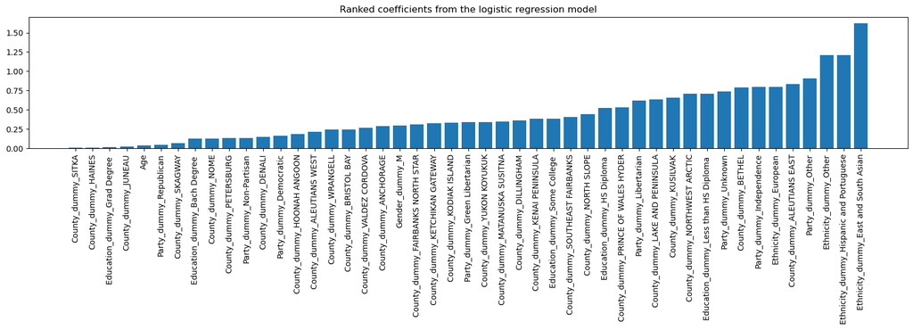

```python
plt.rcParams["figure.figsize"] = (20,3)
plt.xticks(rotation=90)
plt.bar(coefsDF.name, coefsDF.coefs)
plt.title('Ranked coefficients from the logistic regression model')
plt.show()
```

From the barplot, we can observe that `Ethnicity_dummy_East and South Asian` is the most impactful variable in the *training* set compared to the rest of the ones shown since its coefficient is the largest. One could consider how this could have to do with the population densities in Alaska based on ethnicity and if that specific enthinicty had more of a reason to vote. Overall, this visualization implements the foundation of what variables do matter and which ones don’t.

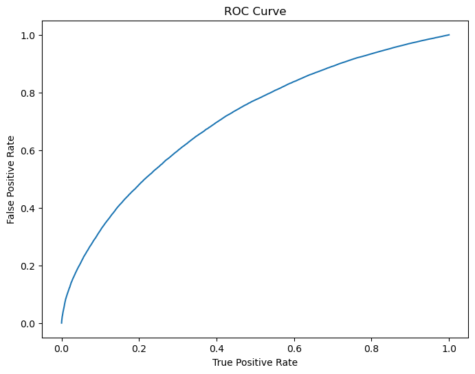

```
Training set areaUnderROC: 0.7056829114633703
```

```python
plt.rcParams["figure.figsize"] = (8,6)

training_summary = lrModel.summary
roc = training_summary.roc.toPandas()
plt.plot(roc['FPR'],roc['TPR'])
plt.ylabel('False Positive Rate')
plt.xlabel('True Positive Rate')
plt.title('ROC Curve')
plt.show()
print('Training set areaUnderROC: ' + str(training_summary.areaUnderROC))
```

The ROC curve is a visualization that explains how well a classification model performs. In our example, we are looking at how well the logistic regression model can distinguish whether Alaskan citizens voted or not in the $2016$ general election. If the area under the ROC curve for the training set is perfect or $100\%$, our model may not be ideal since it could be overfitting the data. In our case, the area under the ROC curve for the training set is $0.7057$. There doesn’t seem to be any overfitting occurring, though we would want to evaluate our model using the test data.

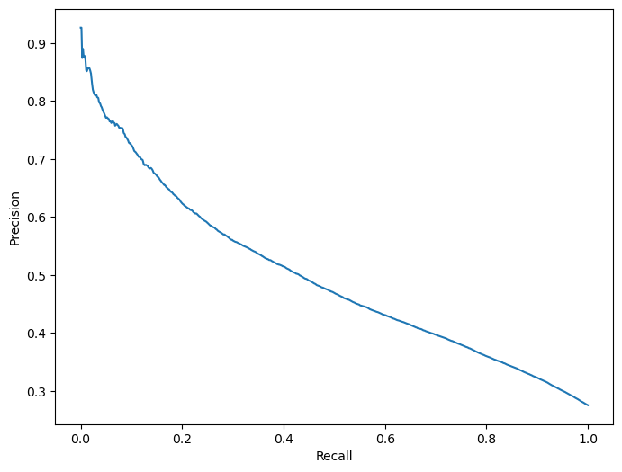

```python
pr = training_summary.pr.toPandas()
plt.plot(pr['recall'],pr['precision'])
plt.ylabel('Precision')
plt.xlabel('Recall')
plt.show()
```

Since our labels are imbalanced (more people who voted than those who didn’t), using the precision-recall (PR) curve can be useful here. Like with the ROC curve, we use the area under the PR curve to determine how well our classification model performs, with an area closer to 1 indicating a better model. From the plot above, we see that the curve is exponentially decreasing – as the recall increases, the precision decreases. The area under this curve for the training data does not seem to be very large, suggesting that the model may not necessarily be a very good classifier.

```python
fittedTest = lrModel.transform(test)
fittedTest.select("label", "prediction", "rawPrediction").show(5, truncate=False)
```

```
[Stage 144:>                                                        (0 + 1) / 1]
```

```
+-----+----------+------------------------------------------+
|label|prediction|rawPrediction                             |
+-----+----------+------------------------------------------+
|0.0  |1.0       |[-0.8997440476341357,0.8997440476341357]  |
|0.0  |1.0       |[-0.6787094122646374,0.6787094122646374]  |
|0.0  |1.0       |[-0.5313529886849718,0.5313529886849718]  |
|0.0  |1.0       |[-0.05244461205105855,0.05244461205105855]|
|0.0  |0.0       |[0.09491181152860706,-0.09491181152860706]|
+-----+----------+------------------------------------------+
only showing top 5 rows
```

Now that the model has been evaluated on the training data, we can now evaluate it on the test data. The table above indicates `label`, the true outcome, `prediction`, the predicted outcome, and `rawPrediction`, the predicted log-odds.

```python
aucEvaluator = BinaryClassificationEvaluator(metricName='areaUnderROC')

aucEvaluator.evaluate(fittedTest)
```

```
0.706698660543756
```

Evaluating the AUC for the testing data returns a value very similar to the one that was evaluated for the training data earlier. This is not the most ideal result because even though $0.7$ is a decent value for AUC, one would want a value closer to $1$ showing that model can distinguish the correct voter turnout outcome more accurately. Having both the training and testing data AUC’s turning out so close to each other means that the model is not overfitting, but it could be doing better.

##### Cross-validation

```python
params = (ParamGridBuilder()
          .addGrid(lr.regParam, np.arange(0, .1, .01))
          .addGrid(lr.elasticNetParam, [0, 1])
          .addGrid(lr.maxIter, [10, 30])
          .build())

# Create cross-validator
cv = CrossValidator(estimator=lr, estimatorParamMaps=params, evaluator=aucEvaluator, numFolds=5)
# Run cross-validation, and choose the best set of parameters
cvModel = cv.fit(train)
predictions = cvModel.transform(test)
```

```python
bestModel = cvModel.bestModel
print('Best Param (regParam): ', bestModel._java_obj.getRegParam())
print('Best Param (MaxIter): ', bestModel._java_obj.getMaxIter())
print('Best Param (elasticNetParam): ', bestModel._java_obj.getElasticNetParam())
```

```
Best Param (regParam):  0.01
Best Param (MaxIter):  30
Best Param (elasticNetParam):  0.0
```

```python
prEvaluator = BinaryClassificationEvaluator(metricName='areaUnderPR')

print('Testing set areaUnderROC with 5-fold CV: ' + str(aucEvaluator.evaluate(predictions)))
print('Testing set prUnderROC with 5-fold CV: ' + str(prEvaluator.evaluate(predictions)))
```

```
Testing set areaUnderROC with 5-fold CV: 0.7092270847825329
Testing set prUnderROC with 5-fold CV: 0.49886712640541386
```

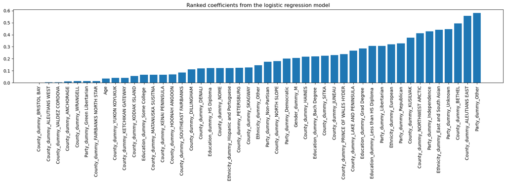

```python
coefsArray = np.array(bestModel.coefficients)  # convert to np.array
coefsDF = pd.DataFrame(np.abs(coefsArray), columns=['coefs'])  # to pandas

coefsDF = coefsDF.merge(featureCols, left_index=True, right_index=True)  # join it with featureCols we created above
coefsDF.sort_values('coefs', inplace=True)  # Sort them

plt.rcParams["figure.figsize"] = (20,3)
plt.xticks(rotation=90)
plt.bar(coefsDF.name, coefsDF.coefs)
plt.title('Ranked coefficients from the logistic regression model')
plt.show()
```

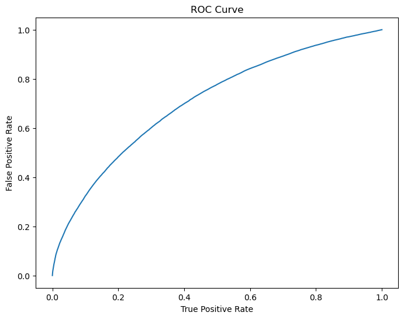

```
Training set areaUnderROC with 5-fold CV: 0.7080004078713547
```

```python
plt.rcParams["figure.figsize"] = (8,6)

training_summary = bestModel.summary
roc = training_summary.roc.toPandas()
plt.plot(roc['FPR'],roc['TPR'])
plt.ylabel('False Positive Rate')
plt.xlabel('True Positive Rate')
plt.title('ROC Curve')
plt.show()
print('Training set areaUnderROC with 5-fold CV: ' + str(training_summary.areaUnderROC))
```

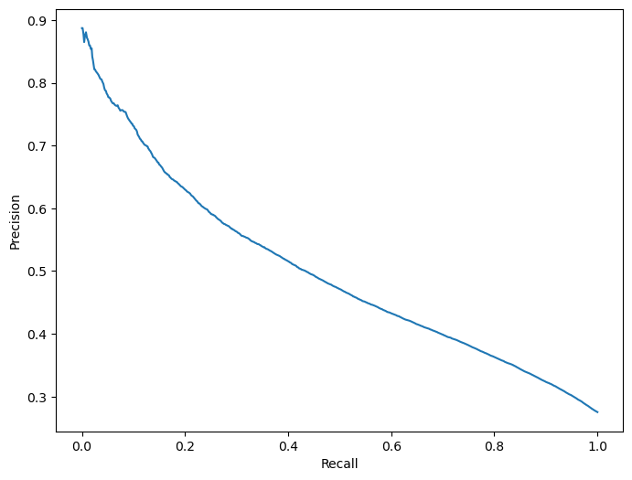

```python
pr = training_summary.pr.toPandas()
plt.plot(pr['recall'],pr['precision'])
plt.ylabel('Precision')
plt.xlabel('Recall')
plt.show()
```

```python
predictions.select("label", "prediction", "rawPrediction").show(5, truncate=False)
```

```
[Stage 8948:>                                                       (0 + 1) / 1]
```

```
+-----+----------+--------------------------------------------+
|label|prediction|rawPrediction                               |
+-----+----------+--------------------------------------------+
|0.0  |1.0       |[-0.8165694851916698,0.8165694851916698]    |
|0.0  |1.0       |[-0.6033488563448288,0.6033488563448288]    |
|0.0  |1.0       |[-0.4612017704469349,0.4612017704469349]    |
|0.0  |0.0       |[7.762587212205574E-4,-7.762587212205574E-4]|
|0.0  |0.0       |[0.1429233446191147,-0.1429233446191147]    |
+-----+----------+--------------------------------------------+
only showing top 5 rows
```

#### Decision Tree

```python
dt = DecisionTreeClassifier(featuresCol="features", labelCol="label", maxDepth=5)
dtModel = dt.fit(train)
fittedTest = dtModel.transform(test)
fittedTest.select("label", "prediction", "rawPrediction", "probability").show(5, truncate=False)
```

```
[Stage 8963:>                                                       (0 + 1) / 1]
```

```
+-----+----------+----------------+----------------------------------------+
|label|prediction|rawPrediction   |probability                             |
+-----+----------+----------------+----------------------------------------+
|0.0  |1.0       |[2521.0,3709.0] |[0.4046548956661316,0.5953451043338683] |
|0.0  |1.0       |[2521.0,3709.0] |[0.4046548956661316,0.5953451043338683] |
|0.0  |1.0       |[624.0,671.0]   |[0.48185328185328186,0.5181467181467182]|
|0.0  |0.0       |[24111.0,9951.0]|[0.7078562621102695,0.29214373788973047]|
|0.0  |0.0       |[24111.0,9951.0]|[0.7078562621102695,0.29214373788973047]|
+-----+----------+----------------+----------------------------------------+
only showing top 5 rows
```

```python
evaluator = BinaryClassificationEvaluator()
evaluator.evaluate(fittedTest, {evaluator.metricName: "areaUnderROC"})
```

```
0.33632864356044817
```

##### Cross-validation

```python
# params = (ParamGridBuilder()
#           .addGrid(dt.maxBins, [10, 20, 40, 80])
#           .addGrid(dt.maxDepth, [2, 10, 30])
#           .build())

# Create cross-validator
# cv = CrossValidator(estimator=dt, estimatorParamMaps=params, evaluator=evaluator, numFolds=5)
# Run cross-validation, and choose the best set of parameters
# cvModel = cv.fit(train)
cvModel = CrossValidatorModel.load("gs://pstat-135-jl/models/dtcv")
predictions = cvModel.transform(test)
```

```python
bestModel = cvModel.bestModel
print('Best Param (maxBins): ', bestModel._java_obj.getMaxBins())
print('Best Param (maxDepth): ', bestModel._java_obj.getMaxDepth())
```

```
Best Param (maxBins):  80
Best Param (maxDepth):  30
```

```python
prEvaluator = BinaryClassificationEvaluator(metricName='areaUnderPR')
print('Testing set areaUnderROC with 5-fold CV: ' + str(evaluator.evaluate(predictions)))
print('Testing set prUnderROC with 5-fold CV: ' + str(prEvaluator.evaluate(predictions)))
```

[output not shown]

```
Testing set areaUnderROC with 5-fold CV: 0.5139352257963238
Testing set prUnderROC with 5-fold CV: 0.3201452450848972
```

#### Random Forest

```python
rf = RandomForestClassifier(featuresCol="features", labelCol="label", numTrees=750)
rfModel = rf.fit(train)
fittedTest = rfModel.transform(test)
fittedTest.select("label", "prediction", "rawPrediction", "probability").show(5, truncate=False)
```

[output not shown]

```
+-----+----------+---------------------------------------+----------------------------------------+
|label|prediction|rawPrediction                          |probability                             |
+-----+----------+---------------------------------------+----------------------------------------+
|0.0  |0.0       |[397.55318844572133,352.44681155427827]|[0.5300709179276287,0.46992908207237133]|
|0.0  |0.0       |[409.8468560810993,340.1531439189001]  |[0.5464624747747995,0.4535375252252005] |
|0.0  |0.0       |[512.4999352206387,237.50006477936077] |[0.6833332469608521,0.31666675303914793]|
|0.0  |0.0       |[523.445433600767,226.55456639923233]  |[0.6979272448010234,0.3020727551989767] |
|0.0  |0.0       |[523.9199826150441,226.08001738495537] |[0.6985599768200593,0.30144002317994073]|
+-----+----------+---------------------------------------+----------------------------------------+
only showing top 5 rows
```

```python
evaluator = BinaryClassificationEvaluator(metricName='areaUnderROC')
prEvaluator = BinaryClassificationEvaluator(metricName='areaUnderPR')
print('Testing set areaUnderROC: ' + str(evaluator.evaluate(fittedTest)))
print('Testing set prUnderROC: ' + str(prEvaluator.evaluate(fittedTest)))
```

```
23/03/19 19:24:53 WARN org.apache.spark.scheduler.DAGScheduler: Broadcasting large task binary with size 3.5 MiB
                                                                                23/03/19 19:24:57 WARN org.apache.spark.scheduler.DAGScheduler: Broadcasting large task binary with size 3.5 MiB
```

```
Testing set areaUnderROC: 0.6938006858331277
Testing set prUnderROC: 0.4948489084526539
```

##### Cross-validation

```python
# params = (ParamGridBuilder()
#           .addGrid(rf.numTrees, [750])
#           .addGrid(rf.maxDepth, [5, 7])
#           .build())

# # Create cross-validator
# cv = CrossValidator(estimator=rf, estimatorParamMaps=params, evaluator=evaluator, numFolds=5)
# # Run cross-validation, and choose the best set of parameters
# cvModel = cv.fit(train)
# predictions = cvModel.transform(test)
```

```python
# bestModel = cvModel.bestModel
# print('Best Param (numTrees): ', bestModel._java_obj.getNumTrees())
# print('Best Param (maxDepth): ', bestModel._java_obj.getMaxDepth())
```

```python
# prEvaluator = BinaryClassificationEvaluator(metricName='areaUnderPR')
# aucEvaluator.evaluate(predictions)
# prEvaluator.evaluate(predictions)

# print('Testing set areaUnderROC: ' + str(evaluator.evaluate(predictions)))
# print('Testing set prUnderROC: ' + str(prEvaluator.evaluate(predictions)))
```

#### Gradient-Boosted Tree

```python
gbt = GBTClassifier(maxIter=10)
gbtModel = gbt.fit(train)
fittedTest = gbtModel.transform(test)
fittedTest.select("label", "prediction", "rawPrediction", "probability").show(5, truncate=False)
```

```
[Stage 9158:>                                                       (0 + 1) / 1]
```

```
+-----+----------+--------------------------------------------+----------------------------------------+
|label|prediction|rawPrediction                               |probability                             |
+-----+----------+--------------------------------------------+----------------------------------------+
|0.0  |1.0       |[-0.35874968797385515,0.35874968797385515]  |[0.32794387488877275,0.6720561251112273]|
|0.0  |1.0       |[-0.2606555726383605,0.2606555726383605]    |[0.37254569521586484,0.6274543047841352]|
|0.0  |0.0       |[0.025519989194467834,-0.025519989194467834]|[0.5127572252520854,0.48724277474791455]|
|0.0  |0.0       |[0.09322231702228273,-0.09322231702228273]  |[0.5464766030181859,0.4535233969818141] |
|0.0  |0.0       |[0.09322231702228273,-0.09322231702228273]  |[0.5464766030181859,0.4535233969818141] |
+-----+----------+--------------------------------------------+----------------------------------------+
only showing top 5 rows
```

```python
evaluator = BinaryClassificationEvaluator()
evaluator.evaluate(fittedTest, {evaluator.metricName: "areaUnderROC"})
```

```
0.7073645392530684
```

##### Cross-validation

```python
# Create parameter grid, add grids for three parameters, and build the parameter grid
# params = (ParamGridBuilder()
#           .addGrid(gbt.maxDepth, [2, 4, 6])
#           .addGrid(gbt.maxBins, [20, 60])
#           .addGrid(gbt.maxIter, [5, 10])
#           .build())

# Create cross-validator
# cv = CrossValidator(estimator=gbt, estimatorParamMaps=params, evaluator=evaluator, numFolds=5)
# cvModel = cv.fit(train)
cvModel = CrossValidatorModel.load("gs://pstat-135-jl/models/gbcv")
predictions = cvModel.transform(test)
```

[output not shown]

```python
bestModel = cvModel.bestModel
print('Best Param (maxBins): ', bestModel._java_obj.getMaxBins())
print('Best Param (maxDepth): ', bestModel._java_obj.getMaxDepth())
print('Best Param (maxIter): ', bestModel._java_obj.getMaxIter())
```

```
Best Param (maxBins):  60
Best Param (maxDepth):  6
Best Param (maxIter):  10
```

```python
prEvaluator = BinaryClassificationEvaluator(metricName='areaUnderPR')
print('Testing set areaUnderROC with 5-fold CV: ' + str(evaluator.evaluate(predictions)))
print('Testing set prUnderROC with 5-fold CV: ' + str(prEvaluator.evaluate(predictions)))
```

```
                                                                                [Stage 9199:>                                                       (0 + 4) / 4]
```

```
Testing set areaUnderROC with 5-fold CV: 0.714759267502886
Testing set prUnderROC with 5-fold CV: 0.5218540520206271
```

#### Neural Network

```python
# Specify layers for the neural network:
# input layer of size 48 (features)
# two intermediate of size 5 and 4
# output layer of size 2 (classes)
layers = [48, 5, 4, 2]
mlp = MultilayerPerceptronClassifier(layers=layers)
mlpModel = mlp.fit(train.select("label", "features"))
fittedTest = mlpModel.transform(train.select("label", "features"))
fittedTest.select("label", "prediction", "rawPrediction", "probability").show(5, truncate=False)
```

```
[Stage 9368:>                                                       (0 + 1) / 1]
```

```
+-----+----------+---------------------------------------+----------------------------------------+
|label|prediction|rawPrediction                          |probability                             |
+-----+----------+---------------------------------------+----------------------------------------+
|0.0  |1.0       |[0.6694605964711076,1.5932109322921044]|[0.2841943542000967,0.7158056457999034] |
|0.0  |1.0       |[0.6694605964711076,1.5932109322921044]|[0.2841943542000967,0.7158056457999034] |
|0.0  |1.0       |[0.7028500237246046,1.5571600329283166]|[0.29852951702295405,0.7014704829770461]|
|0.0  |1.0       |[0.7200003772186417,1.538593222527554] |[0.30606244138998756,0.6939375586100125]|
|0.0  |1.0       |[0.8672648754399177,1.3776775117171263]|[0.37509679893840125,0.6249032010615987]|
+-----+----------+---------------------------------------+----------------------------------------+
only showing top 5 rows
```

```python
aucevaluator = BinaryClassificationEvaluator()
prEvaluator = BinaryClassificationEvaluator(metricName='areaUnderPR')
print('Testing set areaUnderROC: ' + str(aucevaluator.evaluate(fittedTest)))
print('Testing set prUnderROC: ' + str(prEvaluator.evaluate(fittedTest)))
```

```
Testing set areaUnderROC: 0.7067716820801895
Testing set prUnderROC: 0.4981231751247994
```

##### Cross-validation

```python
# Create parameter grid, add grids for three parameters, and build the parameter grid
# params = (ParamGridBuilder()
#           .addGrid(mlp.maxIter, [50, 100])
#           .addGrid(mlp.stepSize, [0.01, 0.1, 0.5])
#           .build())

# Create cross-validator
# cv = CrossValidator(estimator=mlp, estimatorParamMaps=params, evaluator=aucevaluator, numFolds=3)
# cvModel = cv.fit(train)
cvModel = CrossValidatorModel.load("gs://pstat135-cz/models/nncv")
predictions = cvModel.transform(test)
```

[output not shown]

```python
bestModel = cvModel.bestModel
print('Best Param (maxIter): ', bestModel._java_obj.getMaxIter())
print('Best Param (maxStepSize): ', bestModel._java_obj.getStepSize())
```

```
Best Param (maxIter):  100
Best Param (maxStepSize):  0.01
```

```python
prEvaluator = BinaryClassificationEvaluator(metricName='areaUnderPR')
print('Testing set areaUnderROC with 5-fold CV: ' + str(aucevaluator.evaluate(predictions)))
print('Testing set prUnderROC with 5-fold CV: ' + str(prEvaluator.evaluate(predictions)))
```

```
Testing set areaUnderROC with 5-fold CV: 0.7072241535233896
Testing set prUnderROC with 5-fold CV: 0.4966660880885875
```

#### Summary of models

| Model | Best parameters | Number of folds | Testing set areaUnderROC | Testing set prUnderROC |
| --- | --- | --- | --- | --- |
| Logistic regression | `regParam`: 0.01 `MaxIter`: 30 `elasticNetParam`: 0.0 | 5 | 0.7092 | 0.4989 |
| Decision tree | `maxBins`: 80 `maxDepth`: 30 | 5 | 0.5139 | 0.3201 |
| Random forest | `numTrees`: 750 | N/A (due to long training time) | 0.6938 | 0.4948 |
| Gradient-boosted tree | `maxBins`: 60 `maxDepth`: 6 `maxIter`: 10 | 5 | 0.7148 | 0.5219 |
| Neural network | `maxIter`: 100 `maxStepSize`: 0.01 | 3 | 0.7072 | 0.4967 |

These models tend to yield similar results for the area under the ROC and PR curves, with the exception of the decision tree model (which performed significantly worse due to its high variance). We did not perform cross-validation for the random forest model since training it was computationally expensive. The gradient-boosted tree model appears to perform the best on the test data since it has the largest area under both curves. Although the area under the ROC curve for this model is decent ($0.7148$), the relatively low area under the PR curve ($0.5219$) suggests that our “best” model may not necessarily be able to predict voter turnout during the 2016 Alaska general election reliably based on demographic factors alone.

## Discussion

> “All models are wrong, but some are useful.” - George Box

Out of all of the models, the logistic regression model that underwent cross-validation is the most interpretable. Although it is not the best performing one, it has similar ROC-AUC and PR metrics compared to the other models (except the decision tree). The feature importance barplot for the logistic regression model indicates that the most influential factors accounting for change in the log-odds of voter turnout were `Party_dummy_Other`, `County_dummy_ALEUTIANS EAST`, `County_dummy_BETHEL`, `Party_dummy_Unknown`, `Ethnicity_dummy_East and South Asian`, `Party_dummy_Independence`, and `County_dummy_NORTHWEST ARCTIC`. Most of these features rely on counties in Alaska, people with unknown or minority party preferences, or ethnicity. An [article](https://aapidata.com/blog/voting-gains-gaps/) by AAPI Data claims that voter turnout for the Asian American community was at a “record increase” between $2012$ and $2016$; this could influence the amount of pull the `Ethnicity_dummy_East and South Asian` predictor had on the turnout log-odds. Similarly, a majority of the critical features were county-based during the $2016$ Alaskan general election, and this may be because some candidates had solutions for specific issues within these Alaskan communities and therefore motivated them to vote; additionally, it may even be simply attributable to the county population sizes since we did not normalize the turnout rate with respect to each county. Lastly, the `Party_dummy_Other` predictor was surprising based on the earlier exploratory data analysis models showcasing the Republican Party as the most willing to vote. An [article](https://alaskapublic.org/2022/09/15/why-alaska-uses-ranked-choice-voting-and-what-we-know-about-how-it-affects-elections/) written by Alaska Public Media explains how Alaska recently moved to ranked-choice voting in $2020$. Such voting implies that campaign groups must reveal where their funding is coming from, and the funding source could be essential information for voters based on their party. Due to this not being a law in the $2016$ election, it is possible that voters from minority voting parties were misled and did not have as many problems coming out and voting based on presented information from campaign groups. The legal adjustment is specifically relevant to Alaskan voters because Ballot Measure 2 explained above informed them of campaigns with out-of-state funding. To some voters who are likely more conservative or interested in local work, seeing candidates having campaigns with external funding could deter them or encourage them to vote. Withholding funding information could also encourage more voters to vote in $2016$ again to rectify being misled.

In general, this bar plot is one of the most informative and applicable parts of this entire research project if interpreted correctly. For political campaigners, knowing which counties or subpopulations are underrepresented in terms of feature importance is how they decide where or who to focus their efforts on. For example, the plot shows that `County_dummy_BRISTOL BAY` is the least significant predictor in voter turnout. However, this result could be dependent on how many people are living in this specific county. A drawback of evaluating county turnouts is that candidates cannot use the least significant county coefficient as a proxy for underrepresentation. Rather, normalizing turnouts with respect to each county allows for trends in specific counties, ethnicities, incomes, etc. to become more apparent, which can be used to target underrepresented voter groups for more votes in the long run.

One limitation of our analysis is that after preprocessing our data, we were left with around 72.5% of the individuals who voted in the general election. This means that our models may be better at predicting the majority class (those who voted) and worse at predicting the minority class (those who didn’t vote). One idea to remedy this would be to use oversampling or undersampling to ensure that the classes are balanced. Additionally, the large number of missing values caused us to cut our data down to almost a third of its regular size. In a statistical sense, this means we can not generalize our results to the entire state of Alaska. In the future, we could look into imputing the missing values with the mean for numerical columns and the mode for categorical columns. Furthermore, we could also incorporate interaction terms into our model to break the assumption that all of the predictors are independent. In conclusion, based on the logistic regression model, it is apparent that the most influential factors in the 2016 Alaska general election were based on specific parties, counties, and ethnicities.

## References

- [Data Council - How Data is Transforming Politics](https://www.datacouncil.ai/talks/how-data-is-transforming-politics)
- [Kent State University - Chi-Square Test of Independence](https://libguides.library.kent.edu/spss/chisquare)